# Web Scrapping in `R`: An Example Using Wikipedia’s World Population Data

Harvesting Web Data Using `rvest`

Author: John Karuitha

2021-06-19

## **Introduction**

Have you ever come across some valuable data on a website and wished you could access and use it in your research? Did you get discouraged from using useful data from a website because you found the job of writing it down by hand and transferring it to a spreadsheet daunting? Have you ever spent a substantial amount of time trying to copy and paste data from a website with plenty of frustration and headache? If you have found yourself in any of these and similar situations, then this write up is for you. I will highlight the basics of harvesting data from websites, commonly known as web scraping using `R` programming language. I start with the moist common form of data that most financial analysts and economists have interest in: tabular data. In future write ups, I will delve deeper into scrapping websites for text and other types of data and scrapping data that spans multiple web pages of a website. The basics in this section should meet the needs of most unsophisticated users but watch out for more advanced applications of web scrapping.

## **The Target Website and Data**

I have conveniently chosen [wikipedia world population data site](https://en.wikipedia.org/wiki/World_population). The webpage title is `World population`. The webpage contains several tables with world population data broken down by time and continents sourced from the United Nations Population Department (UNPD).

You can visit the site on https://en.wikipedia.org/wiki/World_population

## **Objective and Caveats**

In this article I aim to;

1. Demonstrate the basics of scrapping data tables from a website using `R` and the `rvest` package from the `tidyverse`.
2. Clean the data tables to generate an actionable set of data.

In my analysis, I assume basic knowledge of the `R` programming language. Moreover, my article aims mainly at demonstrating web scrapping and not the analysis of the data. The data cleaning part is a natural extension of web scrapping as most data acquired through web scrapping is rarely clean and hence requires a substantial amount of pre-processing to be useful for analysis.

## **Web Scrapping Intuition**

To appreciate the basics of web-scrapping in any programming language, it is important to grasp the fundamentals of XML, HTML, and CSS. Starting with William W. Tunnicliffe,s presentation in 1967, markup languages have evolved into various forms to suit different applications. Examples include TeX, HTML, XML, and XHTML. I highlight XML, HTML and CSS and how we can take advantage of each to identify the start and end of content we may wish to scrap.

### *XML Tags*

Markup languages have two basic constructs;

- Tags.
- Content.

A tag usually begins with < and ends with a >. The tags come in three flavors.

- Start tags: `<student_name>`. This tag marks the start of content.
- Start tags: `</student_name>`. This tag marks the end of content.
- Empty tags: </>.

The wording in between the < and > is the identifier of the content. In between the beginning and ending tags, we include our content. For instance, we could capture an employee’s name using the following markup code.

`<employee_name> james Peter Onyango </employee_name>`

Hence, we can use the marker employee_name to identify the content we want to capture. We now extend the same idea to HTML and CSS.

### *HTML and CSS Tags*

The Hypertext Markup Language (HTML) is the language that programmers use to create web pages. Usually, HTML combines well with CSS to create elegant web pages. To scrap web pages for data, we have to scan for the following five elements.

- Headers; We construct a HTML header as follows.
- Headings;

Commonly, there are six headers h1 to h6, as follows.

`<h1> Header 1 </h1>`

`<h2> Header 2 </h2>`

`<h3> Header 3 </h3>`

`<h4> Header 4 </h4>`

`<h5> Header 5 </h5>`

`<h6> Header 6 </h6>`

- Paragraphs; A paragraph usually has a tag `p`.

`<p> Paragraph 1 </p>`

`<p> Paragraph 2 </p>`

- Tables; This is the focus of this article. In HTML, tags for tables are as follows.

`<table>` tag that captures main table structure.

`<tbody>` tag that specifies the body of the table.

`<thead>` tag that specifies the table header.

`<tr>` tag that specifies each of the rows of the table.

- Anchors; Anchors allow web developers to attach an URL to some text on a web page. Viewers can then click on the text to activate the link and visit the page. An example of an anchor is as follows.

`<a href="https://rpubs.com/Karuitha/karuitha_cars_pressure"> Click to see my project </a>`

## **The Scrapping Process**

To scrap the web, we first need to read in the web address for the page of interest. We do so using the code below.

```r
library(tidyverse)
library(rvest)
## @knitr enter_url
url_address <- "https://en.wikipedia.org/wiki/World_population"
```

Next, I get the `table` nodes and generate the list containing all the data tables on the page.

```r
## @knitr scraper_code Scrape the page for tables with data
population_tables <- read_html(url_address) %>%
    html_nodes("table") %>%
    html_table()
```

The page has 27 tables. Here are the first two tables.

```r
head(population_tables, 2)
```

```
[[1]]
# A tibble: 13 x 5
   `World population … `World population … `World population… `World population…
   <chr>               <chr>               <chr>              <chr>
 1 "#"                 "Top ten most popu… "2000"             "2015"
 2 "1"                 "China[B]"          "1,270"            "1,376"
 3 "2"                 "India"             "1,053"            "1,311"
 4 "3"                 "United States"     "283"              "322"
 5 "4"                 "Indonesia"         "212"              "258"
 6 "5"                 "Pakistan"          "136"              "208"
 7 "6"                 "Brazil"            "176"              "206"
 8 "7"                 "Nigeria"           "123"              "182"
 9 "8"                 "Bangladesh"        "131"              "161"
10 "9"                 "Russia"            "146"              "146"
11 "10"                "Mexico"            "103"              "127"
12 ""                  "World total"       "6,127"            "7,349"
13 "Notes:\n.mw-parse… "Notes:\n.mw-parse… "Notes:\n.mw-pars… "Notes:\n.mw-pars…
# … with 1 more variable: World population (millions, UN estimates)[15] <chr>

[[2]]
# A tibble: 7 x 5
  Continent  `Density(inhabi… `Population(mil… `Most populous … `Most populous …
  <chr>      <chr>            <chr>            <chr>            <chr>
1 Asia       104.1            4,641            1,439,323,000[n… 37,393,000/13,9…
2 Africa     44.4             1,340            0206,139,000 – … 20,900,000 –  C…
3 Europe     73.4             747              0145,934,000 – … 16,855,000/12,5…
4 Latin Ame… 24.1             653              0212,559,000 – … 22,043,000/12,1…
5 Northern … 14.9             368              0331,002,000 – … 23,724,000/8,32…
6 Oceania    5                42               0025,499,000 – … 4,925,000 –  Sy…
7 Antarctica ~0               0.004[17]        N/A[note 3]      1,258 – McMurdo…
```

And here are the last 2 tables in the page.

```r
tail(population_tables, 2)
```

```
[[1]]
# A tibble: 3 x 6
  X1          X2                            X3    X4            X5    X6
  <chr>       <chr>                         <chr> <chr>         <chr> <chr>
1 Authority … "General\nIntegrated Authori… Gene… Integrated A… Other Microsoft…
2 General     "Integrated Authority File"   <NA>  <NA>          <NA>  <NA>
3 Other       "Microsoft Academic"          <NA>  <NA>          <NA>  <NA>

[[2]]
# A tibble: 2 x 2
  X1      X2
  <chr>   <chr>
1 General Integrated Authority File
2 Other   Microsoft Academic
```

## **Data Cleaning**

I clean the first two tables. This process of cleaning should be done on the particular table of interest. If you need the data in all tables, then you can do the cleaning per table. Note that using `R` to clean data is faster and more accurate than doing it by hand. For data cleaning, you will discover that knowledge of regular expressions (Regex), comes handy.

```r
## @knitr get_data Capture the first few tables and clean the data
first_table <- population_tables %>%
    .[[1]]

first_table_clean <- first_table %>%
    set_names(c("no", "country", "pop_2000", "pop_2015", "pop_2020")) %>%
    filter(no != "#") %>%
    mutate(no = 1:12) %>%
    filter(no != 12) %>%
    mutate(pop_2000 = parse_number(pop_2000), pop_2015 = parse_number(pop_2015),
        pop_2020 = parse_number(pop_2020), country = str_remove_all(country, "\\[.\\]"))

first_table_clean %>%
    knitr::kable(caption = "World's Most Populous Counties 2000-2020 (Millions)",
        booktabs = TRUE) %>%
    kableExtra::kable_styling(full_width = TRUE, bootstrap_options = "striped", font_size = 12)
```

World’s Most Populous Counties 2000-2020 (Millions)

| no | country | pop_2000 | pop_2015 | pop_2020 |
| --- | --- | --- | --- | --- |
| 1 | China | 1270 | 1376 | 1416 |
| 2 | India | 1053 | 1311 | 1528 |
| 3 | United States | 283 | 322 | 356 |
| 4 | Indonesia | 212 | 258 | 295 |
| 5 | Pakistan | 136 | 208 | 245 |
| 6 | Brazil | 176 | 206 | 228 |
| 7 | Nigeria | 123 | 182 | 263 |
| 8 | Bangladesh | 131 | 161 | 186 |
| 9 | Russia | 146 | 146 | 149 |
| 10 | Mexico | 103 | 127 | 148 |
| 11 | World total | 6127 | 7349 | 8501 |

Here, I check out the second table.

```r
my_less_clean_pop <- population_tables %>%
    .[[2]] %>%
    set_names(c("continent", "density", "population", "populous_country", "populous_city")) %>%
    mutate(density = str_remove_all(density, "~") %>%
        parse_number()) %>%
    mutate(population = str_remove_all(population, "\\[.\\]") %>%
        parse_number()) %>%
    mutate(populous_country = str_remove_all(populous_country, "\\[note\\s[0-9]\\]")) %>%
    rename(country_pop = populous_country) %>%
    mutate(populous_country = str_extract(country_pop, "[a-zA-Z]+")) %>%
    mutate(country_pop = parse_number(country_pop)) %>%
    mutate(city_pop = populous_city) %>%
    relocate(populous_country, .after = population) %>%
    select(-populous_city) %>%
    separate(city_pop, into = c("city_population", "city"), sep = "\\s*\\–\\s*") %>%
    mutate(city_population = str_remove_all(city_population, ",")) %>%
    separate(city_population, into = c("city_population", "metro_population", sep = "///")) %>%
    separate(city, into = c("city", "metro"), sep = "/") %>%
    relocate(city, .before = city_population) %>%
    relocate(metro, .before = metro_population) %>%
    mutate(city = if_else(is.na(city), metro, city)) %>%
    mutate(city = str_remove_all(city, "\\[|\\]")) %>%
    mutate(city = str_remove_all(city, "[0-9]")) %>%
    mutate(metro = str_remove_all(metro, "\\[|\\]")) %>%
    mutate(metro = str_remove_all(metro, "[0-9]")) %>%
    select(-10)

my_less_clean_pop
```

```
# A tibble: 7 x 9
  continent        density population populous_country country_pop city
  <chr>              <dbl>      <dbl> <chr>                  <dbl> <chr>
1 Asia               104.    4641     China             1439323000 Greater Toky…
2 Africa              44.4   1340     Nigeria            206139000 Cairo
3 Europe              73.4    747     Russia             145934000 Moscow metro…
4 Latin America       24.1    653     Brazil             212559000 São Paulo Me…
5 Northern Americ…    14.9    368     United             331002000 New York met…
6 Oceania              5       42     Australia           25499000 Sydney
7 Antarctica           0        0.004 N                         NA McMurdo Stat…
# … with 3 more variables: city_population <chr>, metro <chr>,
#   metro_population <chr>
```

## **Data Visualization**

It is a good practice to visualize data before subjecting it to a battery of statistical tests. At times, data visualization can provide such compelling evidence for or against a hypothesis that further statistical tests would not be necessary. I start by visualizing the first dataset.

### Dataset 1: Ten Most Populous Countries (2000-2020)

The league of the top 10 most populous countries globally has remained largely unchanged in the last 20 years. There are two notable issues though.

1. The rise of India as the most populous country in the world, ahead of China.
2. The rapid rise of Nigeria to the fifth most populous country, ahead of Brazil.

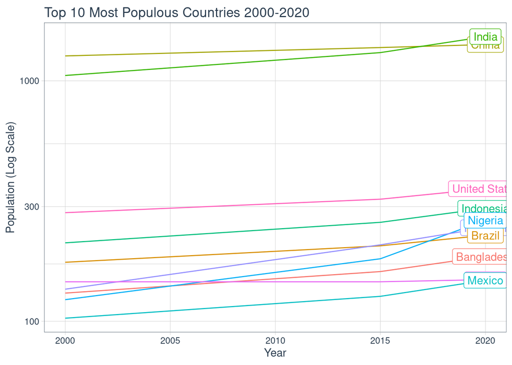

```r
first_table_clean %>%
    select(-no) %>%
    filter(country != "World total") %>%
    pivot_longer(-country, names_to = "year", values_to = "pop") %>%
    mutate(year = parse_number(year)) %>%
    ggplot(aes(x = year, y = pop, col = country)) + geom_line(show.legend = FALSE) +
    geom_label(data = . %>%
        filter(year == "2020"), aes(label = country), show.legend = FALSE) + tidyquant::theme_tq() +
    scale_y_log10() + labs(x = "Year", y = "Population (Log Scale)", title = "Top 10 Most Populous Countries 2000-2020")
```